# Linear Mixed Effect Model

Zhe

10/10/2021

# Preparation

considering the effect of `year` and `state`.

```r
library(ggplot2)
library(GGally)
library(plm) # panel data linear mixed
library(tidyverse)
library(ggfortify)
library(lme4) # linear mixed effect model
library(lmerTest)

data(Produc)  # load the data
head(Produc)
```

|  | state | year | region | pcap | hwy | water | util | pc | gsp | emp | unemp |
| --- | --- | --- | --- | --- | --- | --- | --- | --- | --- | --- | --- |
| 1 | ALABAMA | 1970 | 6 | 15032.67 | 7325.80 | 1655.68 | 6051.20 | 35793.80 | 28418 | 1010.5 | 4.7 |
| 2 | ALABAMA | 1971 | 6 | 15501.94 | 7525.94 | 1721.02 | 6254.98 | 37299.91 | 29375 | 1021.9 | 5.2 |
| 3 | ALABAMA | 1972 | 6 | 15972.41 | 7765.42 | 1764.75 | 6442.23 | 38670.30 | 31303 | 1072.3 | 4.7 |
| 4 | ALABAMA | 1973 | 6 | 16406.26 | 7907.66 | 1742.41 | 6756.19 | 40084.01 | 33430 | 1135.5 | 3.9 |
| 5 | ALABAMA | 1974 | 6 | 16762.67 | 8025.52 | 1734.85 | 7002.29 | 42057.31 | 33749 | 1169.8 | 5.5 |
| 6 | ALABAMA | 1975 | 6 | 17316.26 | 8158.23 | 1752.27 | 7405.76 | 43971.71 | 33604 | 1155.4 | 7.7 |

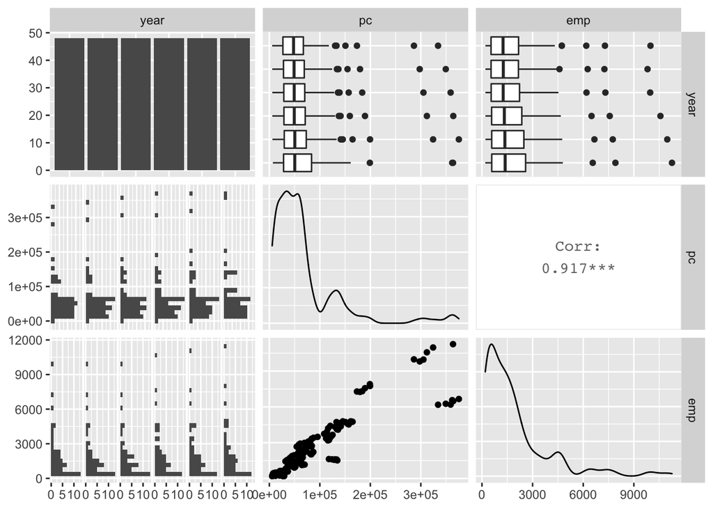

```r
state <- c("AL","AZ","AR","CA","CO","CT","DE","FL","GA","ID","IL","IN",
           "IA","KS","KY","LA","ME","MD","MA","MI","MN","MS","MO","MT",
           "NE","NV","NH","NJ","NM","NY","NC","ND","OH","OK","OR","PA",
           "RI","SC","SD","TN","TX","UT","VT","VI","WA","WV","WI","WY")
Produc$state <- rep(state, each = 17)
data <- Produc %>%
  filter(year > 1980) %>%
  select( state, year, pc, emp)
data$year <- as.factor(data$year)
ggpairs(data[,-1])
```

# Linear Regression: pc ~ emp

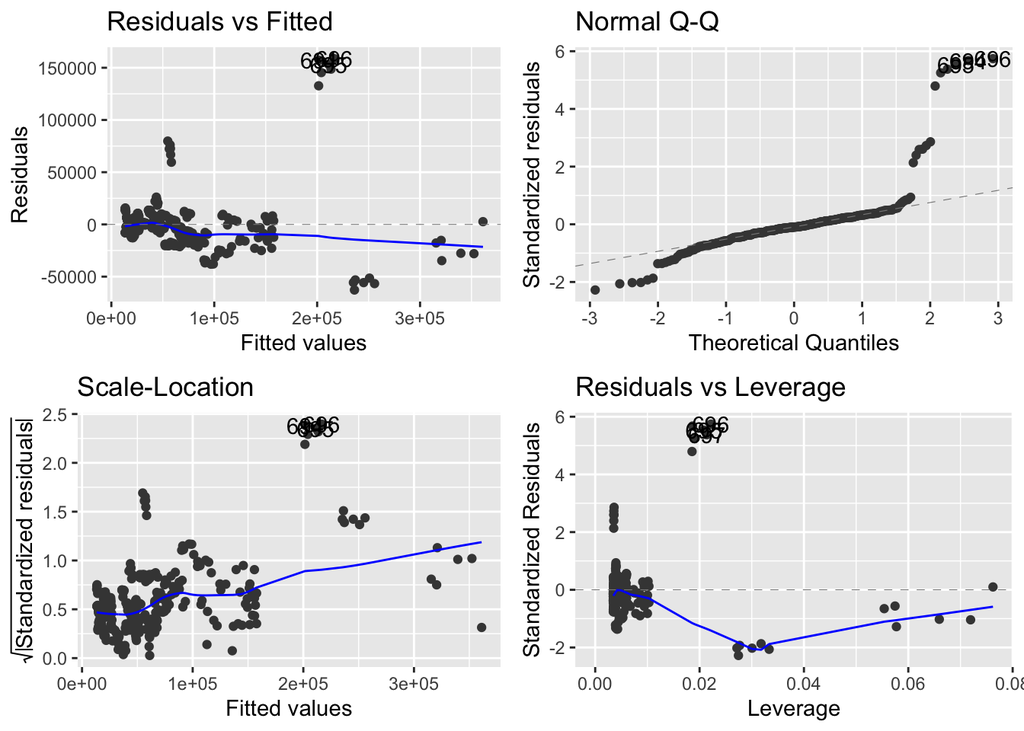

```r
# Fit linear regression
mod1 <- lm(pc ~ emp, data = data)
autoplot(mod1)
```

```r
summary(mod1)
```

```
##
## Call:
## lm(formula = pc ~ emp, data = data)
##
## Residuals:
##    Min     1Q Median     3Q    Max
## -62787 -10491  -2709   5403 158714
##
## Coefficients:
##              Estimate Std. Error t value Pr(>|t|)
## (Intercept) 7078.9203  2271.8141   3.116  0.00202 **
## emp           31.4491     0.8087  38.890  < 2e-16 ***
## ---
## Signif. codes:  0 '***' 0.001 '**' 0.01 '*' 0.05 '.' 0.1 ' ' 1
##
## Residual standard error: 27950 on 286 degrees of freedom
## Multiple R-squared:  0.841,  Adjusted R-squared:  0.8404
## F-statistic:  1512 on 1 and 286 DF,  p-value: < 2.2e-16
```

If we directly fit a linear regression `pc ~ emp`, the diagnostic plots show lots of violation against linear model assumptions. However, before doing any remedy, let’s look at the data.

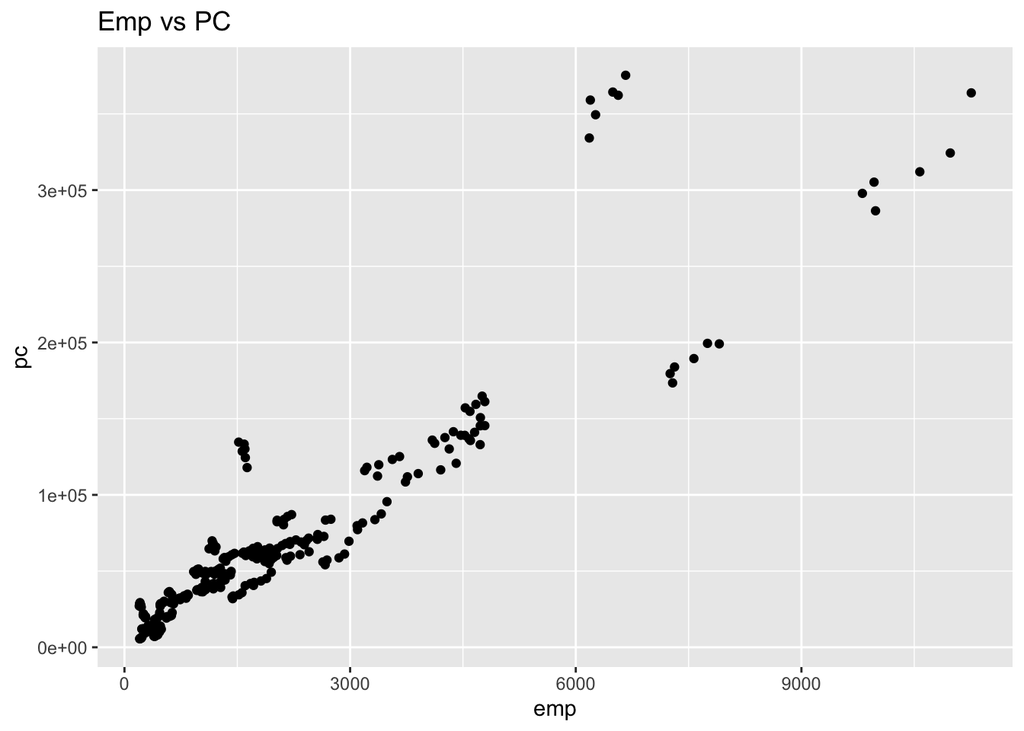

```r
ggplot(data) +
  geom_point(aes(x = emp, y = pc)) + ggtitle("Emp vs PC")
```

The scatter plot show potential linearity, but with some variation. Let’s recreate the scatter plot by year.

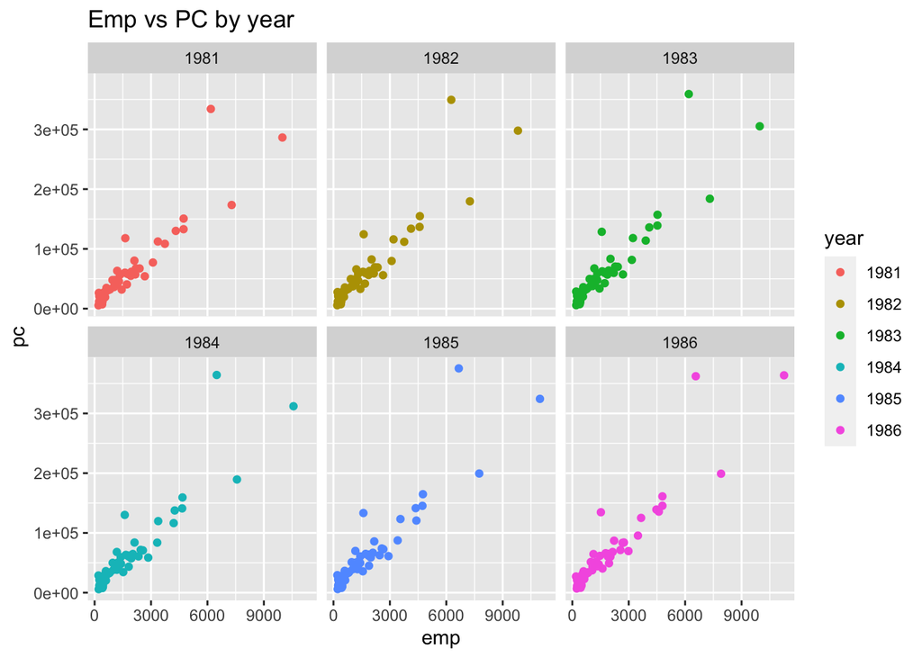

```r
ggplot(data) +
  geom_point(aes(x = emp, y = pc, color = year))  + facet_wrap(~year) + ggtitle("Emp vs PC by year")
```

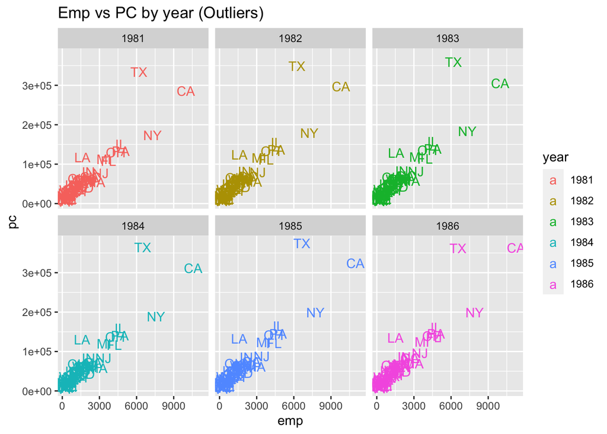

```r
ggplot(data) +
  geom_text(aes(x = emp, y = pc, label = state, color = year))  + facet_wrap(~year)+ ggtitle("Emp vs PC by year (Outliers)")
```

```r
# two outliers: Texas, Louisana,
# leverage points California
```

On this graph, `Texas` and `Louisana` seems to be outliers, while `California` is a leverage point. Delete data from the three states. Since the data has linear relationship if we split the data by year, we add `year` as **fixed effect**.

# Fixed Effect Model: pc ~ emp(fixed effect) + year(fixed effect)

By using fixed effects model, we are assuming the relationship (slope $\beta_1$) between `pc` and `emp` are the same across 6 years. However, due to the different ecnomic situation, the intercepts (or offset, or initial position) are different. Thus, we are going to have 6 **parallel** regression lines.

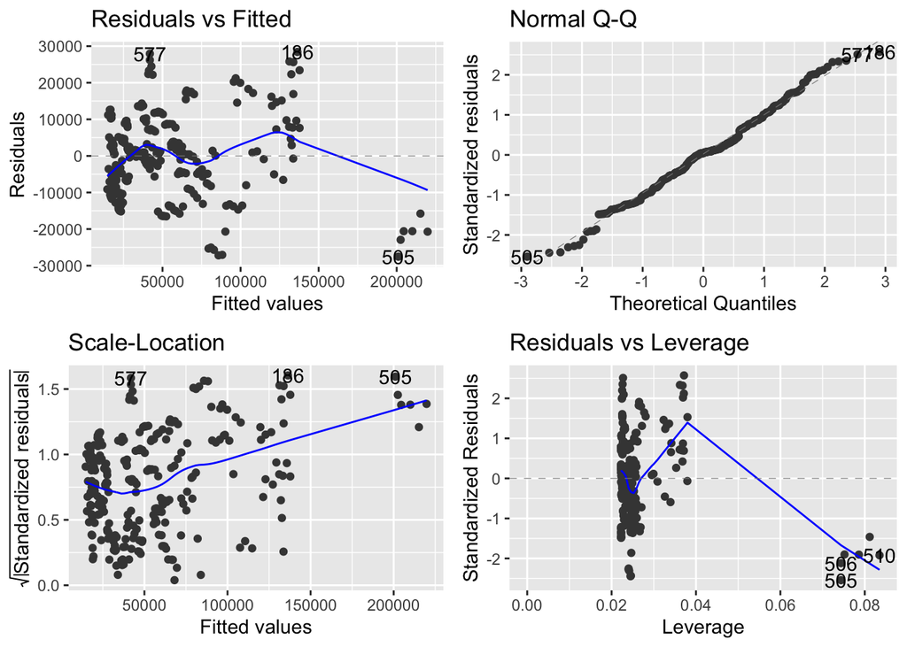

```r
df <- data %>% filter(state !="TX" , state != "LA", state !="CA")
df$year <- as.factor(df$year) # change "year" to factor

# add "year" as a fixed effect
# the slope for "emp" are the same among the 6 year, however each year has a different "intercept"
# the regression lines should be parallel to each other


mod2 <- lm(pc ~ emp + year, data = df)
# check residuals
autoplot(mod2)
```

```r
summary(mod2)
```

```
##
## Call:
## lm(formula = pc ~ emp + year, data = df)
##
## Residuals:
##      Min       1Q   Median       3Q      Max
## -27542.5  -7046.5    492.2   7566.6  28428.7
##
## Coefficients:
##              Estimate Std. Error t value Pr(>|t|)
## (Intercept) 9265.9131  1830.6468   5.062 7.82e-07 ***
## emp           26.3126     0.4531  58.067  < 2e-16 ***
## year1982    2354.0008  2373.8844   0.992    0.322
## year1983    2806.6694  2373.8524   1.182    0.238
## year1984    1566.3448  2373.9819   0.660    0.510
## year1985    1975.5624  2374.3226   0.832    0.406
## year1986    2460.8819  2374.7416   1.036    0.301
## ---
## Signif. codes:  0 '***' 0.001 '**' 0.01 '*' 0.05 '.' 0.1 ' ' 1
##
## Residual standard error: 11260 on 263 degrees of freedom
## Multiple R-squared:  0.9278, Adjusted R-squared:  0.9262
## F-statistic: 563.5 on 6 and 263 DF,  p-value: < 2.2e-16
```

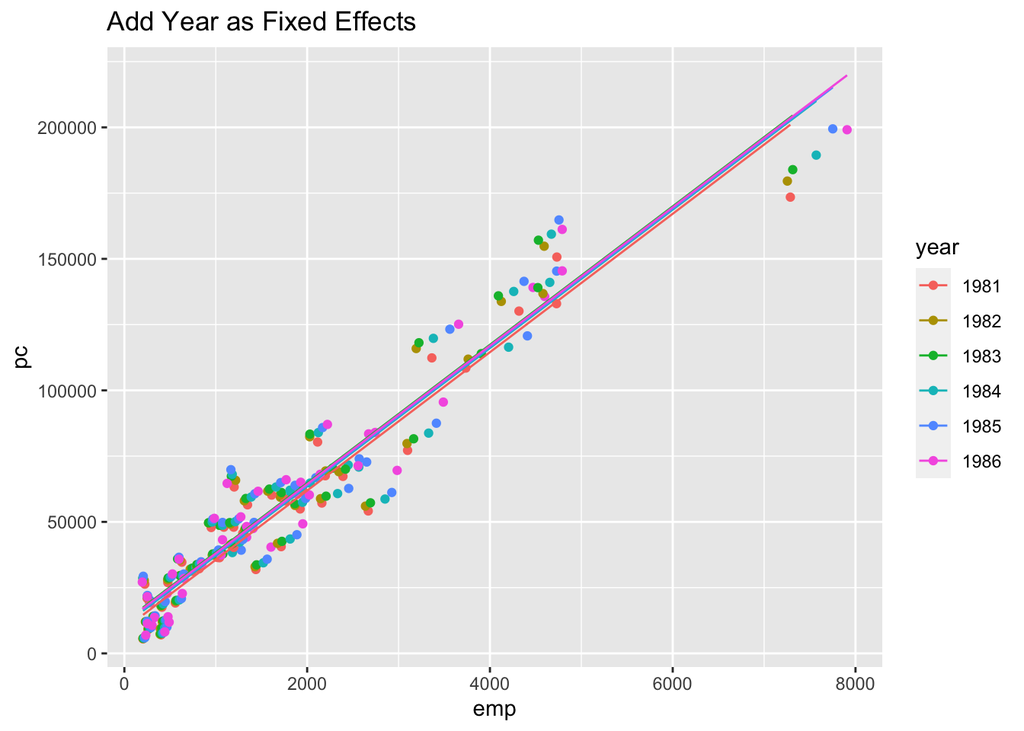

```r
df$pred1 <- mod2$fitted.values


# get parallel regression line with different intercepts

ggplot(df) + geom_point(aes(x = emp, y = pc, color = year,group = year) ) +
  geom_line(aes(x = emp, y = pred1, color = year,group = year) ) + ggtitle("Add Year as Fixed Effects ")
```

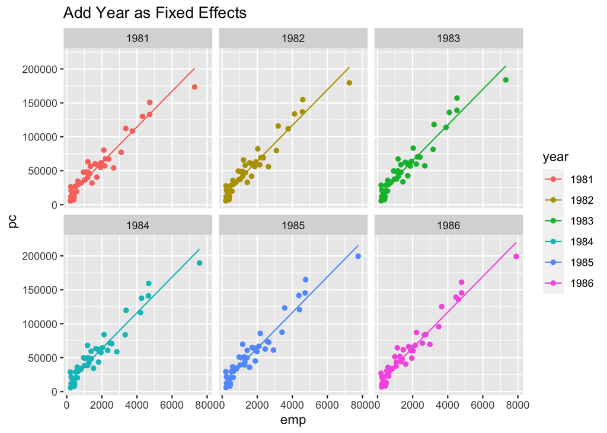

```r
ggplot(df) + geom_point(aes(x = emp, y = pc, color = year)) +
  geom_line(aes(x = emp, y = pred1, color= year)) + facet_wrap(~year) + ggtitle("Add Year as Fixed Effects ")
```

Fixed effects model estimate the fixed effect for each level, here, for each year. Please note the results **can not be extended to another year**, and the inference can only be done for the given time period.

# Random Effect Model: pc ~ state(random intercept)

If we want to consider the difference among different states, `state` can be added into the model. Here, we treat it as **random effects**. Contrast to the fixed effects, the random effects are **unobserved random variables**, not parameters. It can also be some variation that are not important in the study. Instead of focusing on the estimates for each level, we are looking for a general distribution for this variable.

Here, we add a **random intercept** to this model. That is, each state will have its own regression line. These lines are parallel to each other. The random intercepts follows some normal distribution.

```r
# state: random effect
# library(lme4)
# library(lmerTest)

# the default lmer function won't provide p-value
# load "lmerTest" package to get p-values


# Intercept only: random intercept with fixed mean
# pc is predicted by state, a categorical random effect
# intercept is represented by "1"
# "|" means random effect
mod3 <- lmer(pc ~  (1|state) , df)
summary(mod3)
```

```
## Linear mixed model fit by REML. t-tests use Satterthwaite's method [
## lmerModLmerTest]
## Formula: pc ~ (1 | state)
##    Data: df
##
## REML criterion at convergence: 5456.5
##
## Scaled residuals:
##     Min      1Q  Median      3Q     Max
## -3.9577 -0.3279 -0.0456  0.2270  5.1094
##
## Random effects:
##  Groups   Name        Variance  Std.Dev.
##  state    (Intercept) 1.737e+09 41683
##  Residual             1.227e+07  3502
## Number of obs: 270, groups:  state, 45
##
## Fixed effects:
##             Estimate Std. Error    df t value Pr(>|t|)
## (Intercept)    54674       6217    44   8.794 3.01e-11 ***
## ---
## Signif. codes:  0 '***' 0.001 '**' 0.01 '*' 0.05 '.' 0.1 ' ' 1
```

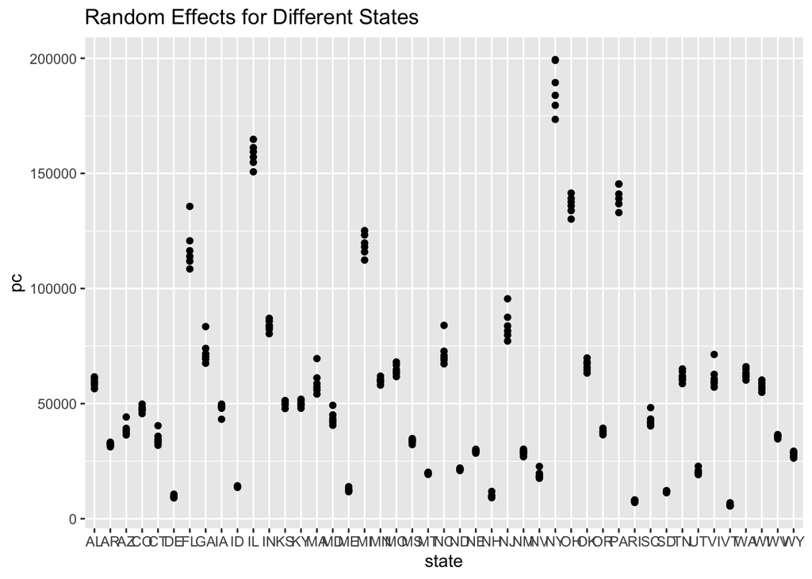

```r
# the variability of the intercept across states is 1.737*10^9
# The intra class correlation is 0.98


ggplot(df) + geom_point(aes(x = state, y = pc)) + ggtitle("Random Effects for Different States")
```

```r
# add state as random intercept, while year as fixed effect,
# we believe there is a difference between the intercept
```

In practice, people rarely use a random intercept only model. But we can add this random intercept into any fixed effect model, to make it a **mixed effect model**.

# Mixed Effect Model

## Random Intercept: pc ~ state(random intercept) + emp(fixed)

We add a random intercept by state to the original linear regression to get the mixed effect model:

```r
mod4 <- lmer(pc ~ (1|state)+ emp  , df)
```

```
## Warning: Some predictor variables are on very different scales: consider
## rescaling

## Warning: Some predictor variables are on very different scales: consider
## rescaling
```

```r
# summary(mod4)
```

We get the warning message saying “Some predictor variables are on very different scales: consider rescaling”. **Scale** the predictor `emp`.

```r
df$emp_s <- (df$emp-mean(df$emp))/sd(df$emp)
mod5 <- lmer(pc ~ (1|state) + emp_s , df)
summary(mod5)
```

```
## Linear mixed model fit by REML. t-tests use Satterthwaite's method [
## lmerModLmerTest]
## Formula: pc ~ (1 | state) + emp_s
##    Data: df
##
## REML criterion at convergence: 5086.5
##
## Scaled residuals:
##     Min      1Q  Median      3Q     Max
## -4.2107 -0.2440  0.0420  0.3574  2.7730
##
## Random effects:
##  Groups   Name        Variance  Std.Dev.
##  state    (Intercept) 124456690 11156
##  Residual               4276403  2068
## Number of obs: 270, groups:  state, 45
##
## Fixed effects:
##             Estimate Std. Error       df t value Pr(>|t|)
## (Intercept) 54673.88    1667.80    43.67   32.78   <2e-16 ***
## emp_s       39913.34    1269.27   119.36   31.45   <2e-16 ***
## ---
## Signif. codes:  0 '***' 0.001 '**' 0.01 '*' 0.05 '.' 0.1 ' ' 1
##
## Correlation of Fixed Effects:
##       (Intr)
## emp_s 0.000
```

```r
# coef(summary(mod5)) # fixed effect estimates
# confint(mod5) # confidence interval for fixed effect estimates
# ranef(mod5) # random effect estimates, we can't calculate confidence interval for random effect
```

The model is significant. Let’s check the residuals. It’s the same as the diagnostics in linear regression.

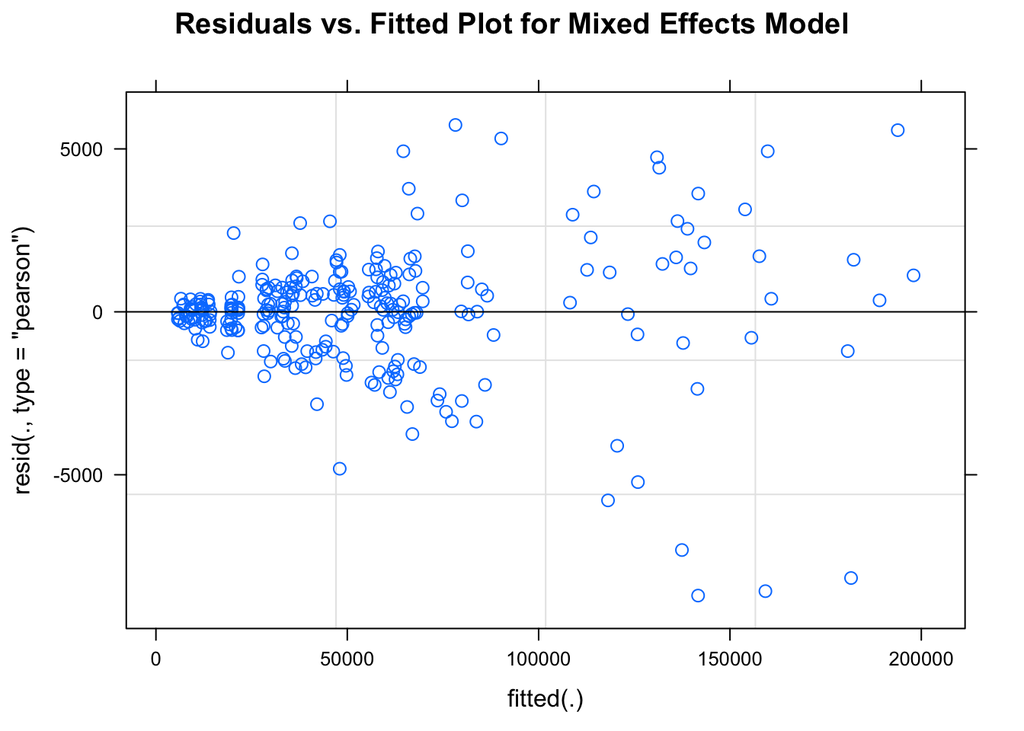

```r
plot(mod5, main = "Residuals vs. Fitted Plot for Mixed Effects Model")
```

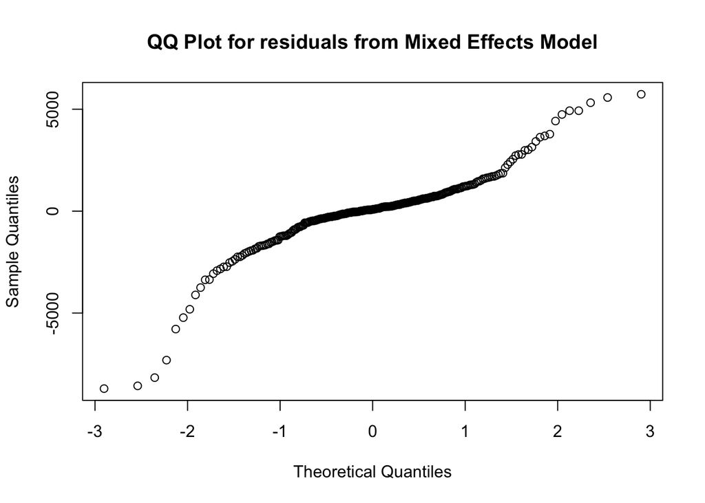

```r
qqnorm(residuals(mod5), main = "QQ Plot for residuals from Mixed Effects Model")
```

The residuals plots suggest that the data need to be transformed. (Econ data, of course!) Perform log transformation and refit the model:

```r
df$logpc <-log(df$pc)
mod6<- lmer(logpc ~ (1|state) + emp_s , df)
summary(mod6)
```

```
## Linear mixed model fit by REML. t-tests use Satterthwaite's method [
## lmerModLmerTest]
## Formula: logpc ~ (1 | state) + emp_s
##    Data: df
##
## REML criterion at convergence: -654.7
##
## Scaled residuals:
##     Min      1Q  Median      3Q     Max
## -2.5631 -0.5775  0.0608  0.3558  3.9260
##
## Random effects:
##  Groups   Name        Variance Std.Dev.
##  state    (Intercept) 0.242602 0.49255
##  Residual             0.001631 0.04039
## Number of obs: 270, groups:  state, 45
##
## Fixed effects:
##              Estimate Std. Error        df t value Pr(>|t|)
## (Intercept)  10.61416    0.07347  42.05024  144.48   <2e-16 ***
## emp_s         0.51900    0.03379 263.63464   15.36   <2e-16 ***
## ---
## Signif. codes:  0 '***' 0.001 '**' 0.01 '*' 0.05 '.' 0.1 ' ' 1
##
## Correlation of Fixed Effects:
##       (Intr)
## emp_s 0.000
```

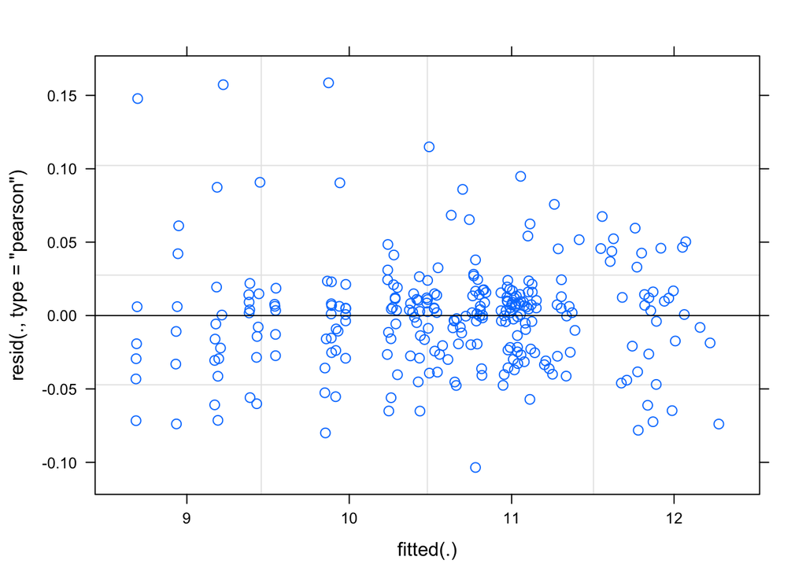

```r
plot(mod6)
```

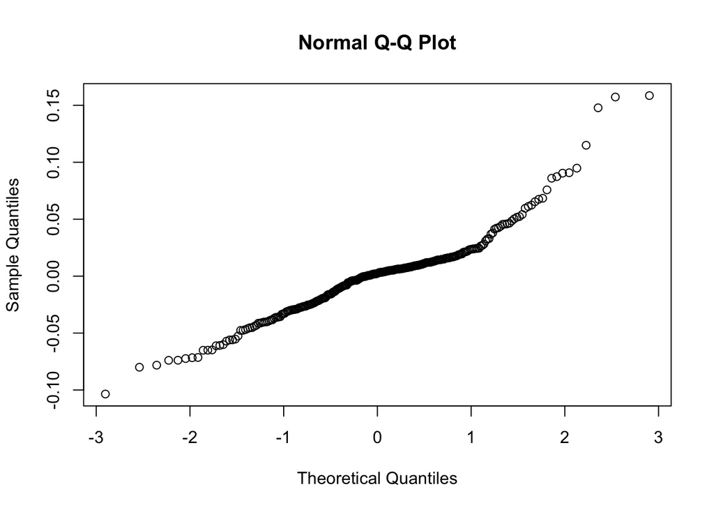

```r
qqnorm(residuals(mod6))
```

The residuals look good. Let’s get the fitted value (for illustration only, we can’t really get the estimation for random effects). Please note our goal is to **find the relationship between `emp` and `pc`**. We don’t care the estimation for random effects.

Let’s plot the results for “AL”, “AZ”, “CO” and “CT”.

```r
ranef(mod6)  # get the estimate for random intercept for each state
```

```
## $state
##    (Intercept)
## AL  0.46833133
## AR  0.07578189
## AZ  0.12224831
## CO  0.25783900
## CT -0.10480453
## DE -0.96512524
## FL  0.22237142
## GA  0.32429287
## IA  0.36209278
## ID -0.61401315
## IL  0.32042408
## IN  0.56419835
## KS  0.44398626
## KY  0.35778086
## MA -0.01395532
## MD  0.02364600
## ME -0.76090185
## MI  0.47618189
## MN  0.34011221
## MO  0.34012386
## MS  0.09665642
## MT -0.25287013
## NC  0.27592028
## ND -0.15554241
## NE  0.02582168
## NH -0.99155704
## NJ  0.17347303
## NM  0.04687365
## NV -0.33533415
## NY -0.47870086
## OH  0.31205541
## OK  0.65334073
## OR  0.14640274
## PA  0.20404309
## RI -1.24944820
## SC  0.19247111
## SD -0.74503172
## TN  0.36831347
## UT -0.32254805
## VI  0.18990220
## VT -1.43085097
## WA  0.43855528
## WI  0.24784259
## WV  0.23033496
## WY  0.11926585
##
## with conditional variances for "state"
```

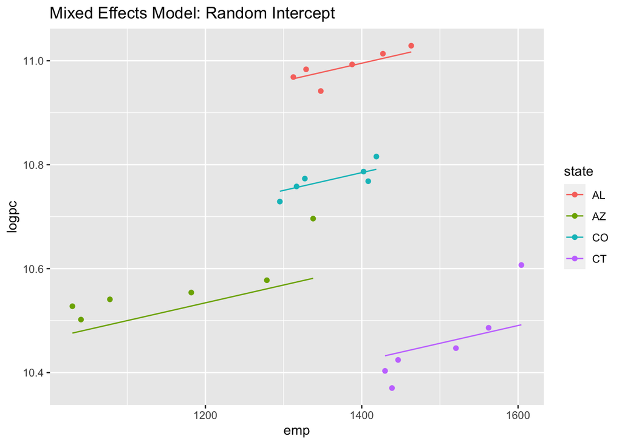

```r
intercept <- 10.61416 # extract from summary(mod6)
slope <- 0.51900   # extract from summary(mod6)
fixed <- intercept + slope * df$emp_s
random <- rep(unlist(ranef(mod6)$state), each =6)
df$pred2 <- fixed + random  # prediction

sub1 <- df %>% filter(state == "AL" | state == "AZ" | state == "CO"| state == "CT" )

# parallel lines
ggplot(sub1) + geom_point(aes(x = emp, y = logpc, color = state, group = state)) +
 geom_line(aes(x = emp, y = pred2, color = state, group = state)) + ggtitle("Mixed Effects Model: Random Intercept")
```

The regression lines share the same slope for `emp` but have random intercepts. Again we should expect parallel regression lines.

## Random Intercept and Random Slope: pc ~ state(random intercept) + emp(random slope)

The random intercept model is the **most realistic and popular** model in practice. However, the reality could be more complicated: the relationship between `pc` and `emp` may be different among the states. That is, both the intercepts and the slopes($\beta_1$) may be different across states. It will lead to a **random intercept** and **random slope** model.

```r
# random slope, random intercept
# Allow each state has its own regression line

mod7 <- lmer(logpc ~ (1 + emp_s|state) + emp_s , df)
summary(mod7)
```

```
## Linear mixed model fit by REML. t-tests use Satterthwaite's method [
## lmerModLmerTest]
## Formula: logpc ~ (1 + emp_s | state) + emp_s
##    Data: df
##
## REML criterion at convergence: -723.3
##
## Scaled residuals:
##     Min      1Q  Median      3Q     Max
## -2.8799 -0.5287  0.0825  0.4310  4.1855
##
## Random effects:
##  Groups   Name        Variance Std.Dev. Corr
##  state    (Intercept) 0.132139 0.3635
##           emp_s       0.066952 0.2587   -0.98
##  Residual             0.001296 0.0360
## Number of obs: 270, groups:  state, 45
##
## Fixed effects:
##             Estimate Std. Error       df t value Pr(>|t|)
## (Intercept) 10.76484    0.05562 33.71353  193.54  < 2e-16 ***
## emp_s        0.64672    0.04192 22.63149   15.43 1.69e-13 ***
## ---
## Signif. codes:  0 '***' 0.001 '**' 0.01 '*' 0.05 '.' 0.1 ' ' 1
##
## Correlation of Fixed Effects:
##       (Intr)
## emp_s -0.857
```

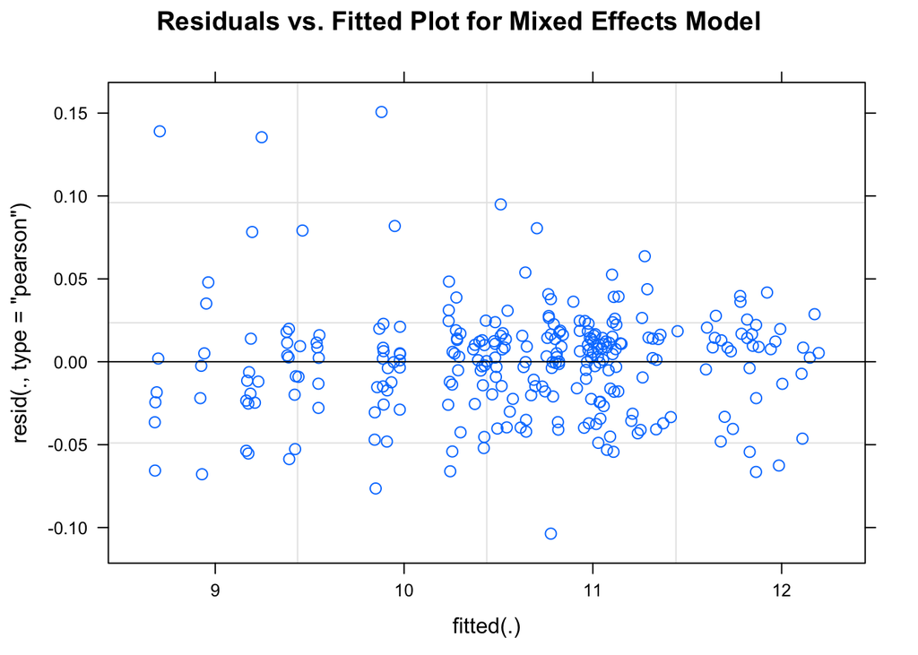

```r
plot(mod7,main = "Residuals vs. Fitted Plot for Mixed Effects Model")
```

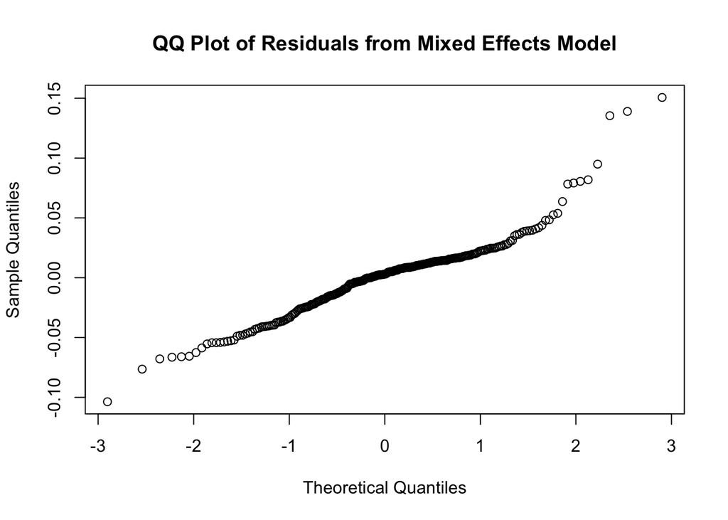

```r
qqnorm(residuals(mod7), main = "QQ Plot of Residuals from Mixed Effects Model")
```

[figure not shown]

```r
# coef(mod7)

df$intercept <- rep(unlist(coef(mod7)$state[1]),each = 6)

df$slope <- rep(unlist(coef(mod7)$state[2]),each = 6)

df$pred3 <- df$intercept + df$slope * df$emp_s

sub2 <- df %>% filter(state == "AL" | state == "AZ" | state == "CO"| state == "CT" )

# non -parallel lines
ggplot(sub2) + geom_point(aes(x = emp, y = logpc, color = state, group = state)) +
 geom_line(aes(x = emp, y = pred2, color = state, group = state)) + ggtitle("Mixed Effects Model: Random Intercept and Random Slope")
```